# MUM 2024-25 Modele ResNet

## Klasy funkcji

- niech $F$ będzie klasą funkcji realizowanych przez jakąś klasę sieci neuronowych
  - jeśli $f_{true}\in{}F$, to mamy szansę ją znaleźć w procesie uczenia

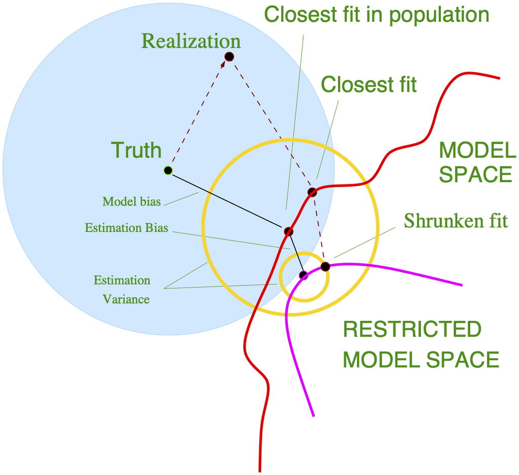

  - w przeciwnym wypadku, szukamy pewnej $f^\ast_F$, najlepszego rozwiązania dla zadanego zbioru danych $$f^\ast_F\stackrel{\text{def}}{=}\arg\min_f\;L(f, X, y)\;\text{takie, że}\;f\in{}F$$
  - regularyzacja Tikhonova pozwala na kontrolę złożoności
- jeśli przestrzeń $F'$ jest *silniejsza* od $F$, to prawdopodobnie algorytm będzie potrafił znaleźć dokładniejszą $f^\ast_{F'}$
  - nie ma jednak żadnej gwarancji jeśli $F\not\subseteq{}F'$
    - $f^\ast_{F'}$ może być nawet gorsza, np. mieć gorszą dokładność
  - konieczne jest zbudowanie ciągu przestrzeni $F_{0}\subseteq{}F_{1}\subseteq{}F_{2}\subseteq{}F_{3}\subseteq{}F_{4}\subseteq{}F_{5}$
    - w sieciach neuronowych można o tym myśleć jako kolejnych warstwach
    - każda kolejna warstwa musi **umieć** realizować model poprzedniej
    - wystarczy dodać do kolejnej warstwy funkcję identyczności $f(x)=x$

[figure not shown]

## Bloki rezydualne

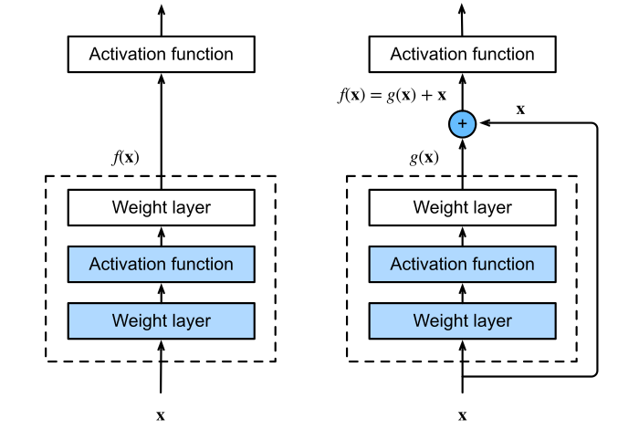

- pomiędzy dwoma warstwami nieliniowa aktywacja
- lepiej dla intuicji jest to zapisać jako $$\begin{align} F(x) &= g(x)\\ &= f(x) - x\\ f(x) &= g(x) + x \end{align}$$
  - w ten sposób blok funkcyjny uczy się poprawki $g(x) = f(x)-x$
  - jeśli $f(x)=x$, to poprawka jest zerowa $g(x)=0$
    - wystarczą zerowe wagi drugiej warstwy bloku ryzydualnego
  - nieliniowa aktywacja po sumie

### zgodność wymiarów

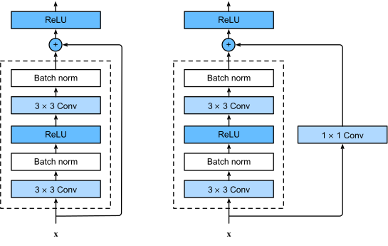

## model ResNet [[He, Zhang, Ren, Sun, *Deep residual learning for image recognition*, 2016]](https://arxiv.org/abs/1512.03385)

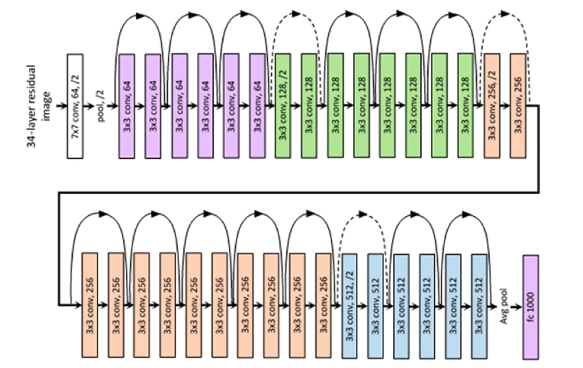

- wiele warstw złożonych z grup
- po każdej następuje blok rezydualny z redukcją
  - BatchNorm po każdej warstwie konwolucji
- kilka predefiniowanych modeli jak ResNet18, ResNet-34, ResNet-152
- uczenie ResNet jest takie same jak innych sieci, przy czym model znacznie lepiej dostosowuje się do problemów
- uczenie ResNet okazuje się bardzo szybkie dzięki efektywnej propagacji
- efektywna inicjalizacja bloków jako realizujących funkcję identyczności
- połączenia skrótowego **wygładza** powierzchnię funkcji kosztu
  - optymalizatory z adaptacyjnymi współczynnikami nauczania chronią przed wpadaniem w lokalne minima
  - prostsze algorytmy, np. SGD, szukają minimów szerzej, często zapewniając lepszą generalizację
  - Adam często działa gorzej dla sieci ResNet niż SGD!

### model Highway [[Srivastava, Greff, Schmidhuber, *Highway networks*, 2015]](https://arxiv.org/pdf/1505.00387.pdf)

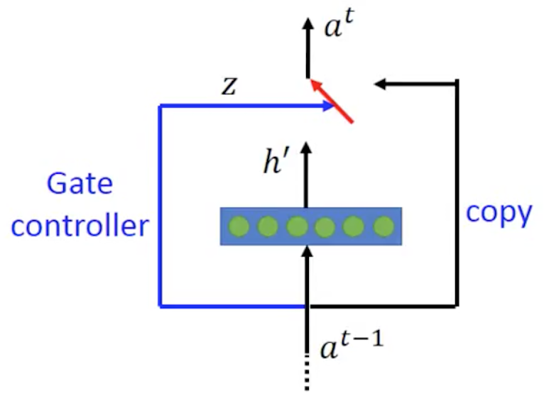

- ResNet przypomina rozwiązanie sieci Highway
  - typowo sieć ma warstwy z aktywacjami typu sigmoidalnego z aktywacją warstwy $y=H(x, W_H)$, gdzie $H$ jest typowo transformacją afiniczną z funkcją nieliniową
  - sieć **highway** ma dodatkowe nieliniowe transformacje $T(x, W_T)$ oraz $C(x, W_C)$ tak, że $$y=H(x, W_H)\cdot{}T(x, W_T)+x\cdot{}C(x, W_C)$$
    - $T(x, W_T)$ jest bramką transformacji
    - $C(x, W_C)$ jest bramką **przeniesienia** (ang. carry)
    - które definiują jak wiele informacji pochodzi z transformacji $H$, a jak wiele z przeniesienia
  - dla prostoty można zdefiniować wprost $C=1-T$ dając $$y=H(x, W_H)\cdot{}T(x, W_T)+x\cdot{}(1-T(x, W_T))$$
  - zwykle $T(x, W_T)=\sigma(W_T^Tx+b_T)$
  - uczenie dla bardzo wielu warstw typowej sieci szybko zatrzymuje się co zależy od inicjaci wag $H$
    - aby początkowo siec przyjmowała zachowanie bardziej w kierunku przeniesienia przez ustawienie **silnego biasu** bramki $b_T<0$
  - taka definicja bramek powoduje, że po osiągnięciu celu, warstwy przestają poprawiać
  - Highway uczy się bardzo efektywnie, szczególnie dla dużej liczby warstw

## model ResNet [[He, Zhang, Ren, Sun, *Deep residual learning for image recognition*, 2016]](https://arxiv.org/abs/1512.03385)

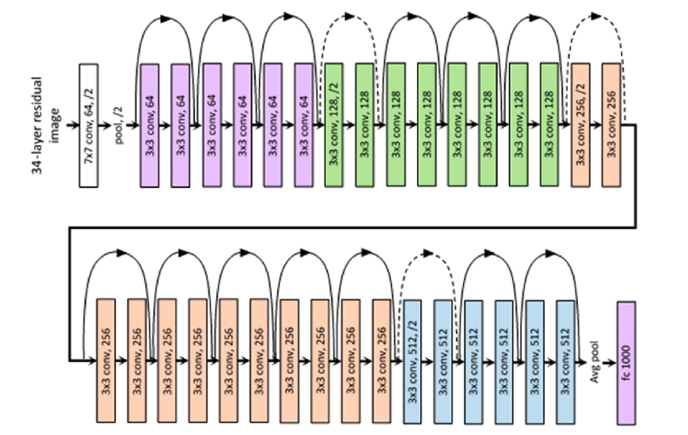

- wiele warstw złożonych z grup
- po każdej następuje blok rezydualny z redukcją
  - BatchNorm po każdej warstwie konwolucji
- kilka predefiniowanych modeli jak ResNet18, ResNet-34, ResNet-152
- uczenie ResNet jest takie same jak innych sieci, przy czym model znacznie lepiej dostosowuje się do problemów
- uczenie ResNet okazuje się bardzo szybkie dzięki efektywnej propagacji
- efektywna inicjalizacja bloków jako realizujących funkcję identyczności
- połączenia skrótowego **wygładza** powierzchnię funkcji kosztu
  - optymalizatory z adaptacyjnymi współczynnikami nauczania chronią przed wpadaniem w lokalne minima
  - prostsze algorytmy, np. SGD, szukają minimów szerzej, często zapewniając lepszą generalizację
  - Adam często działa gorzej dla sieci ResNet niż SGD!

### model Highway [[Srivastava, Greff, Schmidhuber, *Highway networks*, 2015]](https://arxiv.org/pdf/1505.00387.pdf)

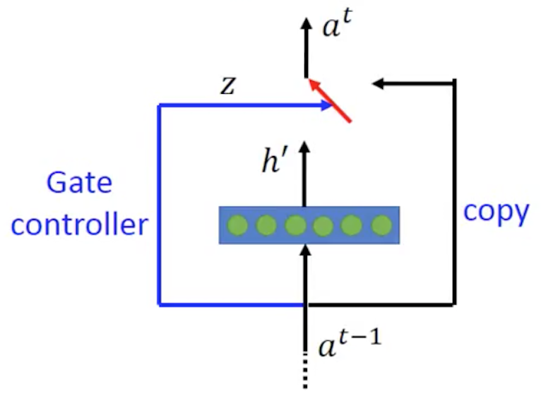

- ResNet przypomina rozwiązanie sieci Highway
  - typowo sieć ma warstwy z aktywacjami typu sigmoidalnego z aktywacją warstwy $y=h(x, W_h)$, gdzie $h$ jest typową siecią z aktywacją nieliniową
  - sieć **highway** ma dodatkowe nieliniowe transformacje $z(x, W_z)$ oraz $C(x, W_C)$ tak, że $$a^t=y=h'(x, W_{h'})\cdot{}z(x, W_z)+x\cdot{}C(x, W_C)$$ dla $x=a^{t-1}$
    - $z(x, W_z)$ jest bramką transformacji
    - $C(x, W_C)$ jest bramką **przeniesienia** (ang. carry)
    - które definiują jak wiele informacji pochodzi z transformacji $h'$, a jak wiele z przeniesienia
  - dla prostoty można zdefiniować wprost $C=1-T$ dając $$a^t=y=h'(x, W_{h'})\cdot{}z(x, W_z)+x\cdot{}(1-z(x, W_z))$$
  - zwykle $z(x, W_z)=\sigma(W_z^Tx+b_z)$
  - uczenie dla bardzo wielu warstw typowej sieci szybko zatrzymuje się co zależy od inicjaci wag $W_{h'}$
    - aby początkowo siec przyjmowała zachowanie bardziej w kierunku przeniesienia przez ustawienie **silnego biasu** bramki $b_z<0$
  - taka definicja bramek powoduje, że po osiągnięciu celu, warstwy przestają poprawiać
  - Highway uczy się bardzo efektywnie, szczególnie dla dużej liczby warstw

## ResNeXt

- w ResNet problemem jest równowaga między nieliniowością a wymiarowością w bloku
  - rozwiązaniem może być dodanie pewnej liczby warstw
  - zwiększenie szerokości konwolucji w blokach
  - zwiększenie liczby kanałów pomiędzy blokami

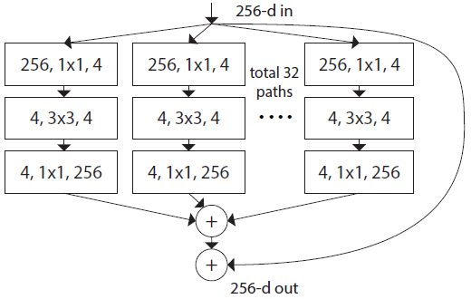

- **podzielenie kanałów na grupy**
  - dzielimy $c_{in}$ kanałów na $g$ grup o wymiarach $c_{in}/g$
    - $c_{in}$ podzielne przez $g$
    - dla każdej grupy konwolucje 1x1 dające b kanałów (dla każdej grupy)
      - zwiększenie wymiarowości
    - niezależnie konwolucje dla każdej grupy dając b/g kanałów
  - wyniki wszystkich g grup są konkatenowane dając b kanałów
  - aby wymiarowość się zgadzała, potrzebne są konwolucje 1x1 z b do c kanałów

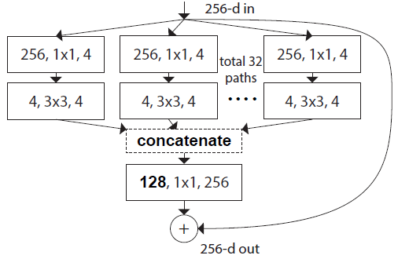

- rozwiązanie ResNext dodatkowo jest **wydajne**!
  - oryginalnie złożoność jest proporcjonalna do $c_{in}\times{}c_{out}$
  - teraz proporcjonalna do $g\times{}(c_{in}/g)\times{}(c_{out}/g)=c_{in}\times{}c_{out}/g$
  - umieszczenie konwolucji 1x1 **na końcu** daje złożoność rzędu $c\cdot{}b$ zamiast $b^2/g$ przy konwolucjach 1x1 na końcu każdej grupy
  - dobre implementacje potrafią dobrze wykorzystać równoległe użycie wielu GPU
- jednak kanały w grupach **nie dzielą informacji między sobą**!
  - ktoś pamięta? — AlexNet dzielił kanały na dwie grupy!
  - odpowiednia końcowa konwolucja 1x1 pozwala także częściowo wykorzystać informacje między kanałami
    - na rysunku konkatenacja daje 128 kanałów
    - konwolucja 1x1 generuje oczekiwane 256 kanałów i łączy informacje między nimi
- takie dzielenie przypomina AlexNet
  - tam dla oszczędności pamięci, kanały były rozdzielone między dwa GPU!
- wciąż te modele są **sprytnie** zaprojektowane, a brakuje pewnej **automatyczności**

## DenseNet [[Huang, Liu, van der Maaten, Weinberger, *Densely connected convolutional networks*]](https://arxiv.org/pdf/1608.06993.pdf)

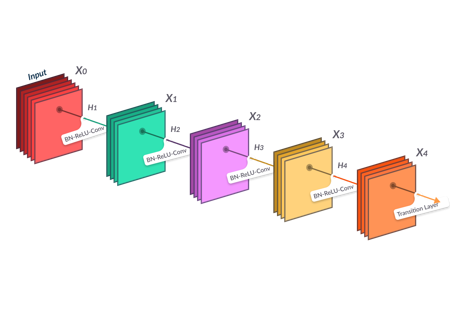

- ResNet dzieli funkcję na $f(x)=x+g(x)$ - prosty element liniowy i funkcję
- szereg Taylora rozbija wartość funkcji na szereg składników $$\begin{align} f(x)=f(x_0)&+\dfrac{f'(x_0)}{1!}(x-x_0)+\dots\\ &+\dfrac{f^{(n-1)}(x_0)}{n!}(x-x_0)^{n-1}\\ &+r_n(x,x_0) \end{align}$$
- ResNet **dodaje** wartości wejściowej i przetworzonej

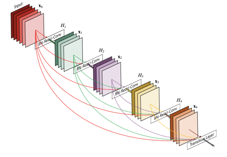

- DenseNet natomiast **konkatenuje** bardzo wiele wartości uzyskanych przez kolejne funkcje $$\begin{align} x\longrightarrow[&x,\; f_1(x),\;\; \\ &f_2([x,\; f_1(x)]),\;\; \\ &f_3([x,\; f_1(x),\; f_2([x,\; f_1(x)])),\;\dots] \end{align}$$
  - architektura ma bardzo wiele połączeń zależnych od wszystkich poprzednich bloków

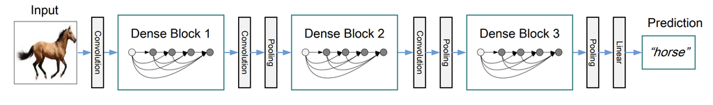

- każdy moduł będzie dodawał bardzo wiele kanałów
  - dodanie zbyt wielu spowoduje zbyt dużą liczbę parametrów i złozony model
  - architektura DenseNet będzie podzielona na bloki
    - bloki Dense będą rozdzielone blokami **przejściowymi** (transition)
      - każdy blok transition zwykle zmniejsza liczbę kanałów konwolucjami 1x1
      - dodatkowo zmniejsza dwukrotnie wymiar przez pooling (stride=2)
- DenseNet może być bardzo obciążające pamięciowo i wymaga dobrej kontroli
  - znowu mamy model wymagający **sprytnego** projektowania